# Transition entropy of AI assistant interaction sequences

Nestimate

2026-04-27

## The analytic question

Given the AI assistant has just produced a coded action — *Plan*, *Execute*, *Repair*, … — how predictable is what comes next? Two summaries answer this at different scales. Per-state row entropy $H(P_{i\cdot})$ measures how dispersed the outgoing transitions from state $i$ are. The chain-level **entropy rate** $h(P) = \sum_i \pi_i H(P_{i\cdot})$ aggregates row entropies under the long-run stationary distribution $\pi$ and is the Shannon–McMillan–Breiman per-step uncertainty of trajectories [Cover & Thomas, 2006, ch. 4]. The deficit $H(\pi) - h(P)$ quantifies how much the order-1 Markov structure compresses the process below the i.i.d. baseline.

## Data

`ai_long` contains 8,551 coded AI-assistant turns across 428 sessions and 34 projects, classified into 8 fine-grained codes and 3 super-class clusters (Action / Communication / Repair).

```r
data(ai_long, package = "Nestimate")
str(ai_long)
```

```
## 'data.frame':    8551 obs. of  9 variables:
##  $ message_id      : int  3441 3441 3443 3443 3445 3447 3449 3449 3449 3451 ...
##  $ project         : chr  "Project_7" "Project_7" "Project_7" "Project_7" ...
##  $ session_id      : chr  "0086cabebd15" "0086cabebd15" "0086cabebd15" "0086cabebd15" ...
##  $ timestamp       : int  1772661600 1772661600 1772661600 1772661600 1772661600 1772661600 1772661600 1772661600 1772661600 1772661600 ...
##  $ session_date    : chr  "2026-03-05" "2026-03-05" "2026-03-05" "2026-03-05" ...
##  $ code            : chr  "Delegate" "Plan" "Execute" "Plan" ...
##  $ cluster         : chr  "Action" "Repair" "Action" "Repair" ...
##  $ code_order      : int  1 2 1 2 1 1 1 2 3 1 ...
##  $ order_in_session: int  5 6 8 9 12 14 17 18 19 23 ...
```

```r
table(code = ai_long$code)
```

```
## code
##         Ask    Delegate     Execute     Explain Investigate        Plan
##          99         295        3258         524        2317        1620
##      Repair      Report
##         257         181
```

## Building the transition network

`build_network()` consumes the long-format data directly, identifies the session boundary via `id_col`, and orders events by `time`. The `"relative"` method row-normalises raw transition counts to produce a proper Markov transition matrix.

```r
net_codes <- build_network(
  ai_long,
  method  = "relative",
  id_col  = "session_id",
  action  = "code",
  time    = "order_in_session"
)
round(net_codes$weights, 3)
```

```
##               Ask Delegate Execute Explain Investigate  Plan Repair Report
## Ask         0.033    0.033   0.286   0.484       0.099 0.033  0.022  0.011
## Delegate    0.007    0.025   0.182   0.050       0.093 0.621  0.014  0.007
## Execute     0.010    0.022   0.510   0.055       0.247 0.116  0.030  0.010
## Explain     0.020    0.016   0.256   0.131       0.313 0.069  0.083  0.111
## Investigate 0.009    0.016   0.252   0.035       0.221 0.437  0.018  0.012
## Plan        0.010    0.048   0.470   0.060       0.303 0.032  0.040  0.037
## Repair      0.052    0.040   0.474   0.171       0.235 0.016  0.008  0.004
## Report      0.006    0.062   0.377   0.111       0.284 0.031  0.086  0.043
```

Each row sums to one, so `net_codes$weights` is the maximum-likelihood estimator of the AI’s order-1 transition matrix.

## Per-state branching: which codes are most predictable?

```r
te_codes <- transition_entropy(net_codes, base = 2)
te_codes
```

```
## Transition Entropy (8 states, bits)
##
## Entropy rate       h(P)  = 2.0521 bits
## Stationary entropy H(pi) = 2.2381 bits
## Redundancy         H(pi) - h(P) = 0.1860 bits
##
## Per-state row entropy:
##         Ask    Delegate     Execute     Explain Investigate        Plan
##      2.0328      1.7310      1.9944      2.5372      2.0122      2.0757
##      Repair      Report
##      2.0265      2.3479
```

Per-state row entropy is bounded above by $\log_2 8 = 3$ bits (uniform branching across all 8 codes) and below by 0 (deterministic next code).

```r
summary(te_codes)
```

```
## Transition Entropy - Summary (bits)
##
##        state stationary row_entropy contribution
##          Ask     0.0121      2.0328       0.0246
##     Delegate     0.0268      1.7310       0.0464
##      Execute     0.4055      1.9944       0.8088
##      Explain     0.0659      2.5372       0.1673
##  Investigate     0.2496      2.0122       0.5022
##         Plan     0.1849      2.0757       0.3839
##       Repair     0.0324      2.0265       0.0656
##       Report     0.0227      2.3479       0.0533
##
## Entropy rate       h(P)  = 2.0521 bits
## Stationary entropy H(pi) = 2.2381 bits
## Redundancy         H(pi) - h(P) = 0.1860 bits
```

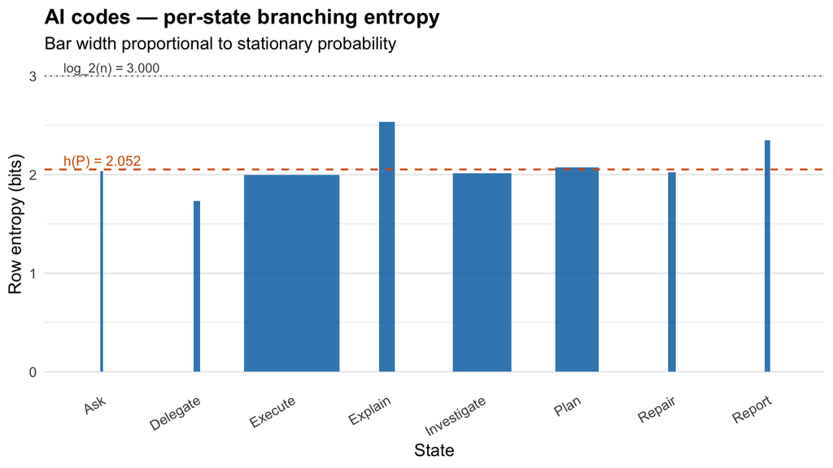

```r
plot(te_codes, title = "AI codes — per-state branching entropy")
```

Bar widths in the plot are proportional to stationary probability, so the total visual area sums to the entropy rate $h(P)$. The dashed orange line is $h(P)$, the dotted grey line is the uniform-branching upper bound $\log_2 n$.

## Chain-level summary

```r
te_codes$entropy_rate
```

```
## [1] 2.052114
```

```r
te_codes$stationary_entropy
```

```
## [1] 2.238133
```

```r
te_codes$redundancy
```

```
## [1] 0.1860186
```

```r
te_codes$redundancy / te_codes$stationary_entropy
```

```
## [1] 0.08311329
```

Entropy rate $h(P) =$ 2.052 bits/step; stationary entropy $H(\pi) =$ 2.238 bits. The redundancy ratio $\big(H(\pi) - h(P)\big) / H(\pi) =$ 0.083 says the order-1 Markov memory removes about 8 % of the uncertainty an i.i.d. process at the same marginals would carry. The chain has structure, but a single-step memory is far from a deterministic predictor.

The maximum theoretical entropy rate at this state-space cardinality is $\log_2 8 = 3$ bits. The observed 2.05 bits represents 68.4 % of that maximum — the AI’s coded action stream is closer to “moderately uncertain” than to “random”.

## Coarsening to 3 super-class clusters

When the same sequences are re-coded at the cluster level (Action, Communication, Repair), the state space shrinks from 8 to 3 and so does the maximum entropy ($\log_2 3 \approx 1.585$).

```r
net_clusters <- build_network(
  ai_long,
  method  = "relative",
  id_col  = "session_id",
  action  = "cluster",
  time    = "order_in_session"
)
te_clusters <- transition_entropy(net_clusters, base = 2)
te_clusters
```

```
## Transition Entropy (3 states, bits)
##
## Entropy rate       h(P)  = 1.1371 bits
## Stationary entropy H(pi) = 1.2024 bits
## Redundancy         H(pi) - h(P) = 0.0653 bits
##
## Per-state row entropy:
##        Action Communication        Repair
##        1.1939        1.3447        0.8754
```

```r
c(
  fine   = te_codes$entropy_rate    / log2(8),
  coarse = te_clusters$entropy_rate / log2(3)
)
```

```
##      fine    coarse
## 0.6840382 0.7174261
```

Normalising each entropy rate by the appropriate $\log_2 n$ ceiling removes the trivial state-space-size effect. The two ratios show how much of the maximum uncertainty each granularity actually attains. A sharp drop on coarsening would indicate the cluster scheme is capturing real grouping structure; a flat ratio indicates the cluster boundaries are essentially arbitrary cuts through a homogeneous transition surface.

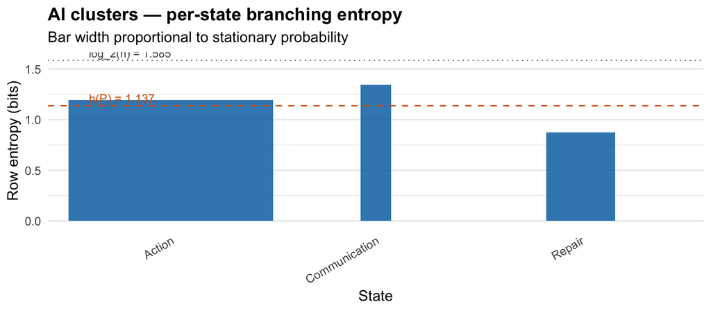

```r
plot(te_clusters, title = "AI clusters — per-state branching entropy")
```

## Group dispatch: per-project entropy rates

`transition_entropy()` dispatches on `netobject_group` so a per-project analysis is one extra argument to `build_network()`.

```r
projects_keep <- names(which(table(ai_long$project) >= 100))
ai_subset <- ai_long[ai_long$project %in% projects_keep, ]

net_by_project <- build_network(
  ai_subset,
  method = "relative",
  id_col = "session_id",
  action = "code",
  time   = "order_in_session",
  group  = "project"
)
te_by_project <- transition_entropy(net_by_project, base = 2)
te_by_project
```

```
## Transition Entropy - 13 groups: Project_7, Project_24, Project_17, Project_13, Project_25, Project_33, Project_9, Project_5, Project_21, Project_26, Project_8, Project_10, Project_11
##
## Entropy rate per group:
##  Project_7 Project_24 Project_17 Project_13 Project_25 Project_33  Project_9
##     2.0883     2.0198     1.8622     2.1368     1.9186     1.9320     1.9387
##  Project_5 Project_21 Project_26  Project_8 Project_10 Project_11
##     2.0246     1.7428     1.4491     1.9611     1.9760     1.9010
```

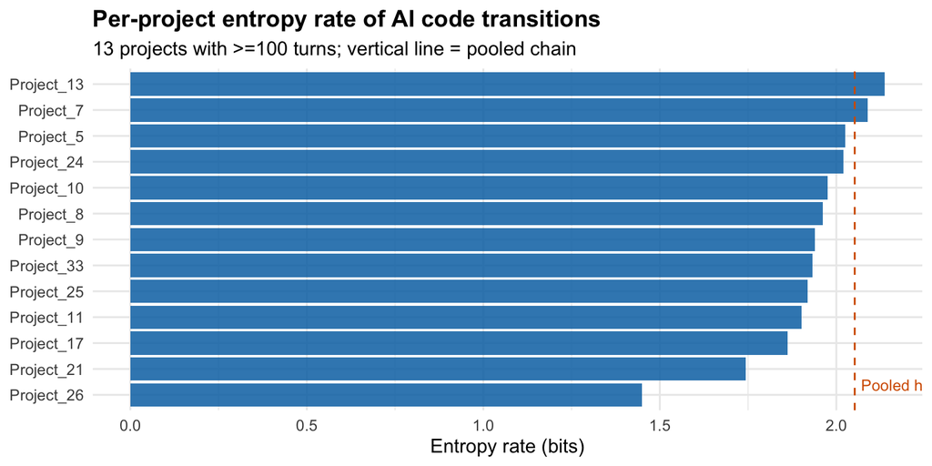

```r
rates <- vapply(te_by_project, function(o) o$entropy_rate, numeric(1))
df_rates <- data.frame(
  project      = names(rates),
  entropy_rate = unname(rates)
)
df_rates <- df_rates[order(df_rates$entropy_rate), ]
df_rates$project <- factor(df_rates$project, levels = df_rates$project)

ggplot(df_rates, aes(x = entropy_rate, y = project)) +
  geom_col(fill = "#0072B2", alpha = 0.85) +
  geom_vline(xintercept = te_codes$entropy_rate,
             linetype = "dashed", colour = "#D55E00") +
  annotate("text", x = te_codes$entropy_rate, y = 1,
           label = sprintf("Pooled h(P) = %.2f", te_codes$entropy_rate),
           hjust = -0.05, vjust = -0.4, colour = "#D55E00", size = 3.4) +
  labs(x = "Entropy rate (bits)", y = NULL,
       title = "Per-project entropy rate of AI code transitions",
       subtitle = sprintf("%d projects with >=100 turns; vertical line = pooled chain",
                         nrow(df_rates))) +
  theme_minimal(base_size = 12) +
  theme(plot.title = element_text(face = "bold"))
```

The spread across projects measures how strongly project context shapes the AI’s order-1 behaviour. Projects clustered tightly around the pooled $h(P)$ would indicate a stable, project-invariant behavioural profile; wide spread indicates project-specific transition regimes that a single pooled model would average over.

## Validation

`transition_entropy()` is validated to machine precision against an independent reference composition built from `markovchain::steadyStates()` and `entropy::entropy.plugin()`. Across 100 random irreducible aperiodic configurations spanning 3–7 states with log bases 2, $e$, 10:

| Quantity | Max abs error | Tolerance |
| --- | --- | --- |
| Entropy rate $h(P)$ | 6.66 × 10⁻¹⁶ | 1 × 10⁻¹⁰ |
| Stationary $H(\pi)$ | 8.88 × 10⁻¹⁶ | 1 × 10⁻¹⁰ |
| Per-row $H(P_{i\cdot})$ | 8.88 × 10⁻¹⁶ | 1 × 10⁻¹⁰ |
| Stationary $\pi$ | 4.44 × 10⁻¹⁶ | 1 × 10⁻⁸ |

Reproduce with `NESTIMATE_EQUIV_TESTS=true Rscript -e 'devtools::load_all("."); testthat::test_file("local_testing_and_equivalence/test-equiv-transition_entropy.R")'`.

## When to use which

| Quantity | Reads as |
| --- | --- |
| `row_entropy[i]` | uncertainty of the AI’s *next* code given it just emitted code $i$ |
| `stationary_entropy` | i.i.d. baseline; the entropy of the marginal-state distribution |
| `entropy_rate` | irreducible per-step trajectory uncertainty under the order-1 chain |
| `redundancy` | bits of memory the chain captures at order 1; zero iff i.i.d. |

Pair `transition_entropy()` with `markov_order_test()` to ask whether the order-1 entropy rate is the *true* asymptotic rate or whether longer memory still removes uncertainty. Pair it with `chain_structure()` to verify the chain is regular before interpreting $\pi$ as a stable long-run distribution; for non-regular chains $\pi$ is non-unique and the entropy rate is conditional on the recurrent class assumed.

## References

Cover, T.M., Thomas, J.A. (2006). *Elements of Information Theory*, 2nd ed., chapter 4. Wiley.

Shannon, C.E. (1948). A mathematical theory of communication. *Bell System Technical Journal*, **27**, 379–423.